title: “MovieLens Predictions” author: “Andrew Antenen” date: “3/26/2022” output: html_document —

```r
source('getdata.R')
source('movieLens.R')
```

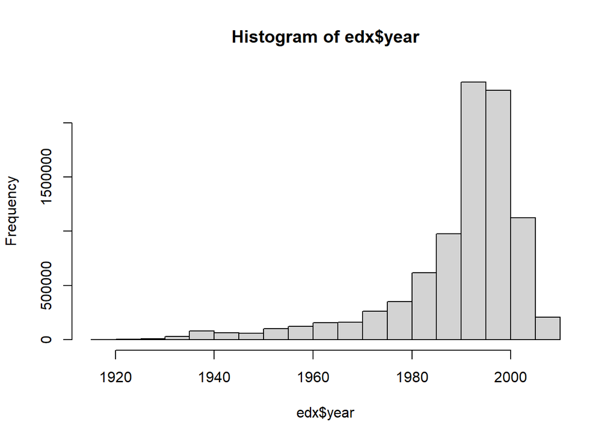

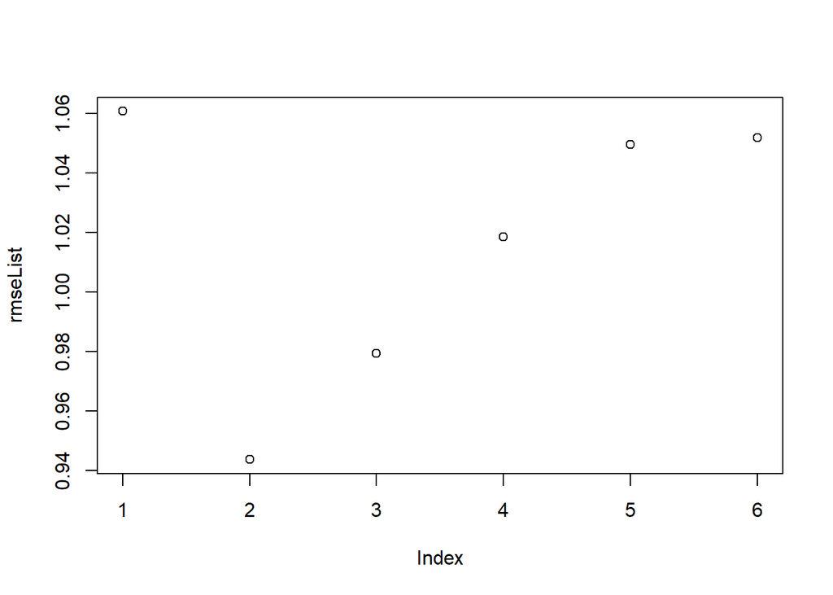

```r
library(dplyr)
library(ggplot2)
```

# Introduction

This report details attempts to create a model for predicting user movie ratings based on the MovieLens dataset. Based on the massive size of data options for models were limited.

Models were built using value effects and regularization to predict future ratings. Many different combinations of affects were tested before the final model was determined.

#Data validation and cleansing

First validated that there are no blank values. All values in dataset are present.

Then validate that all values are valid and make sense.

```r
cntChart<-function(x){x%>%ggplot(aes(group,cnt,color=avg))+
    geom_point(aes(size=avg))+
    scale_color_gradientn(colors=heat.colors(10))
}

avgChart<-function(x){
  y<-as.numeric(as.numeric(max(x$group))-as.numeric(min(x$group)))
  y<-y*.25
  x%>%ggplot(aes(group,avg,color=cnt))+
    geom_point(aes(size=cnt))+
    scale_color_gradientn(colors=heat.colors(10))
    #scale_x_continuous(breaks = seq(min(x$group),max(x$group),y))
    }

knitr::kable(data.frame(measure = c("rating","year","age"),min=c(min(edx$rating),min(as.numeric(edx$year)),min(edx$age)),
          max=c(max(edx$rating),max(as.numeric(edx$year)),max(edx$age))))
```

| measure | min | max |
| --- | --- | --- |
| rating | 0.5 | 5 |
| year | 1915.0 | 2008 |
| age | -2.0 | 93 |

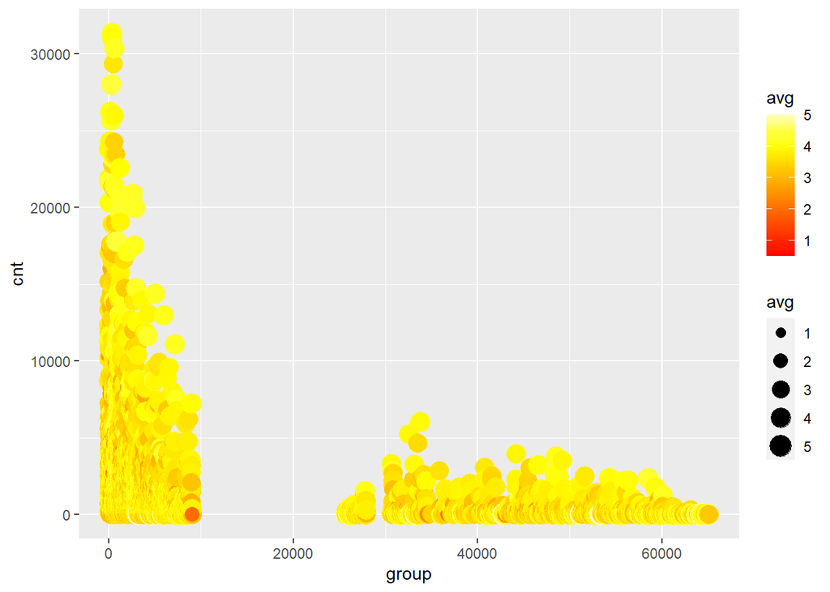

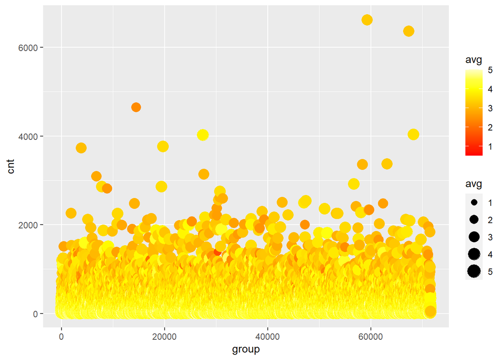

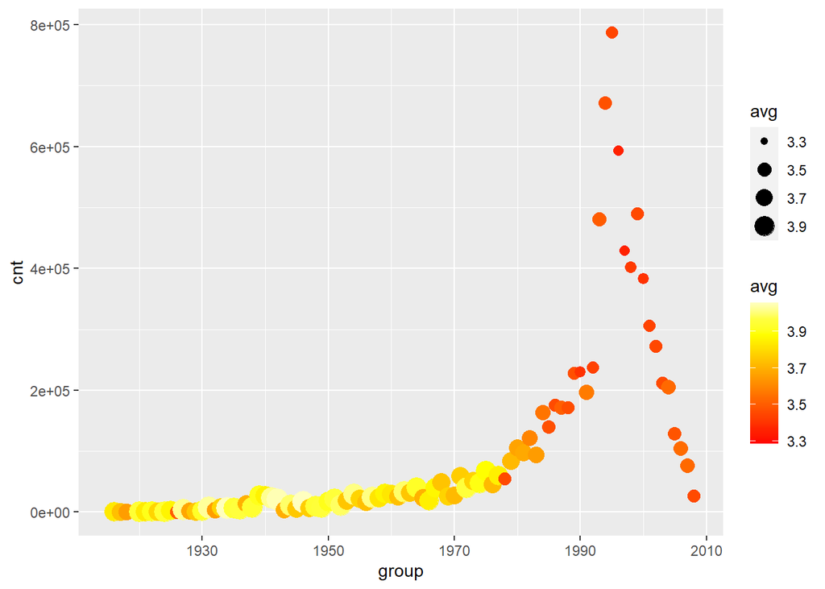

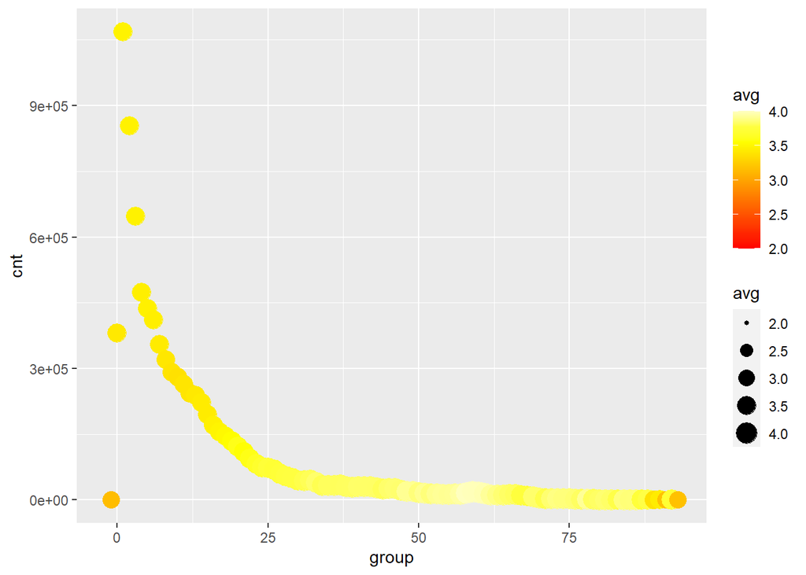

```r
# avgRatingChart<-function(x){
#   y<-min(group)
#   z<-max(group)
#   edxMovie%>%ggplot(aes(group,avg))+
#     geom_boxplot(aes(group=cut_width(group,3)))+
#     scale_x_discrete(breaks=seq(min(group),max(group),500))
# }


# avgRatingChart(edxMovie)
#cntChart(edxMovie)
chartValues<-list(edxMovie,edxUser,edxYear,edxAge)
lapply(chartValues,cntChart)
```

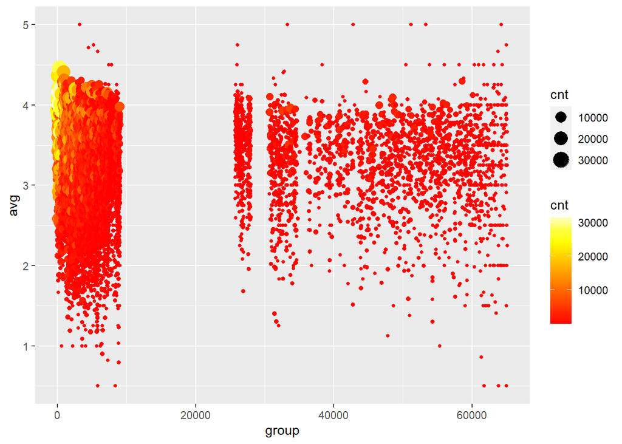

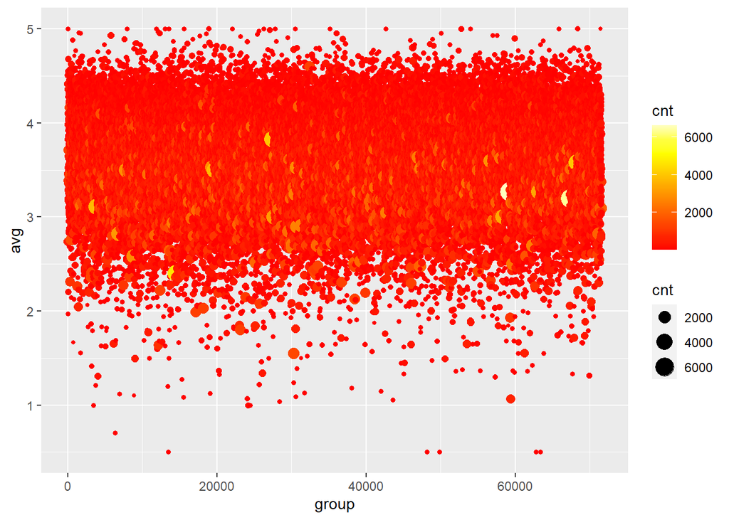

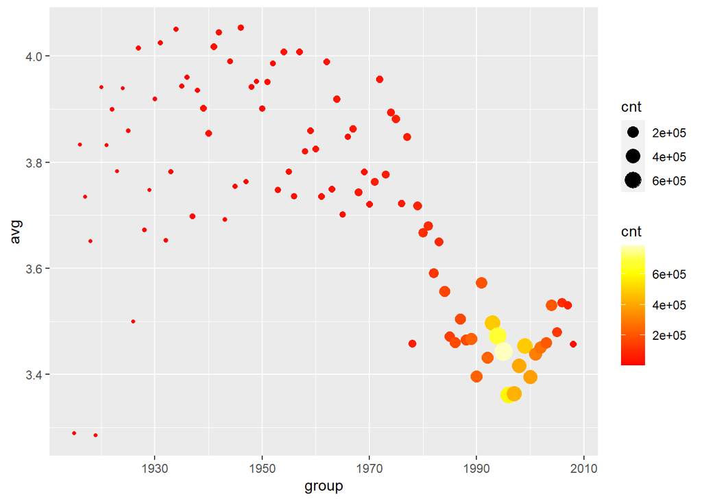

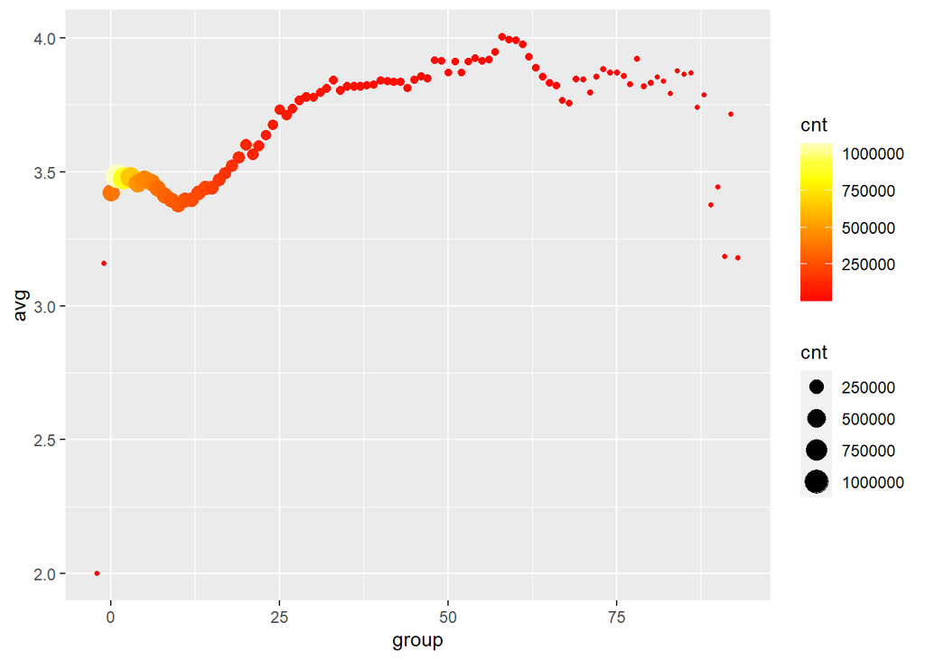

```r
lapply(chartValues,avgChart)
```

As seen in the chart the movieIds are missing for many Ids in the middle of the dataset, which is strange but should not affect the data.

#Models Initially a naive approach was used, to predict ratings, the full dataset average

```r
overallAvgRating
```

```
## [1] 3.512045
```